# Report

By Marcellinus Jerricho, Edward Jeremy Lo, Rana Harris Farooq

## Content

The report contains the following:

1. Introduction
2. EDA
3. Research Question
4. Prediction
5. Conclusion

```python
# importing necessary modules
import pandas as pd
import numpy as np
import os
import re
import matplotlib.pyplot as plt
np.random.seed(42)
plt.style.use('fivethirtyeight')
%matplotlib inline
```

## Introduction

**Research Question:** Does the number of penalties score, number of penalties taken, team’s payroll (total salary paid annually), and stadium capacity influence the team's penalty success rate?

The three datasets we use are:

1. [Football penalty kicks](https://www.kaggle.com/emilerichard/penalty-statistics-20192020) from the 2019-2020 season from Bundesliga, Serie A, Ligue 1, English Premier League, and the European Champions League.
2. The [payroll](https://www.capology.com) of each club: the total amount of salary each club paid in that year, in Euros and GBP.
3. The [stadium capacity](https://data.world/johayes13/football-soccer-stadiums) of each match.

## EDA

### Importing Datasets

```python
# 1) Penalty kicks
# PT = Penalty Taker
columns_to_drop = ['Pen taker', 'Journee', 'Date',
                   'LtD game-changing pen', 'DtW game-changing pen',
                   'L no game-changing', 'W no game-changing', 'PT sub', 'Last Goal']
penalty_stats = pd.read_csv('penalty_stats_19_20.csv').drop(columns=columns_to_drop).dropna()

# get the dummies
columns_to_get_dummies = ['Team taking pen', 'Scored', 'Team win']
penalty_stats_dummies = pd.get_dummies(penalty_stats[columns_to_get_dummies], drop_first=True)

# combining penalty
columns_to_join = ['Competition', 'Home team', 'Away team', 'Minute', 'PT position']
penalty = penalty_stats[columns_to_join].join(penalty_stats_dummies)

# getting the team taking penalty
def get_PT_team(row):
    if row['Team taking pen_Home']:
        return row['Home team']
    return row['Away team']

penalty['PT team'] = penalty.apply(get_PT_team, axis=1)
penalty.head()
```

|  | Competition | Home team | Away team | Minute | PT position | Team taking pen_Home | Scored_YES | Team win_YES | PT team |
| --- | --- | --- | --- | --- | --- | --- | --- | --- | --- |
| 0 | Premier League | West Ham | Manchester City | 84.0 | ST | 0 | 0 | 1 | Manchester City |
| 1 | Premier League | West Ham | Manchester City | 86.0 | ST | 0 | 1 | 1 | Manchester City |
| 2 | Premier League | Manchester United | Chelsea | 18.0 | W | 1 | 1 | 1 | Manchester United |
| 3 | Premier League | Aston Villa | Bournemouth | 2.0 | OM | 0 | 1 | 1 | Bournemouth |
| 4 | Premier League | Wolverhampton | Manchester United | 68.0 | DM | 0 | 0 | 0 | Manchester United |

```python
# 2) Payrolls
# getting individual datasets
bundesliga = pd.read_csv('bundesliga.csv')[['Club', 'Annual Gross (IN EUR']]
ligue1 = pd.read_csv('ligue-1.csv')[['Club', 'Annual Gross (IN EUR']]
serieA = pd.read_csv('serieA.csv')[['Club', 'Annual Gross (IN EUR']]
laliga = pd.read_csv('la-liga.csv')[['Club', 'Annual Gross (IN EUR']]
primeiraliga = pd.read_csv('primeira-liga.csv')[['Club', 'Annual Gross (IN EUR']]
# NOTE: epl is in GBP, not in EUR
epl = pd.read_csv('epl.csv')[['Club', 'Annual Gross (IN GBP']]\
        .rename(columns={'Annual Gross (IN GBP': 'Payroll'}).drop_duplicates('Club')

# defining functions to convert the currency to float
def get_payroll_float(payroll_str):
    '''
    Convert the payroll in string into payroll in integers.
    '''
    payroll_int = float("".join(re.findall('\d+', payroll_str)))
    return payroll_int * 1000

def convert_GBP_to_EUR(payroll_gbp):
    '''
    Convert the payroll from GBP currency to EUR currency for EPL
    Source: https://www.exchangerates.org.uk/GBP-EUR-spot-exchange-rates-history-2019.html#:~:text=Average%20exchange%20rate%20in%202019%3A%201.1405%20EUR.
    '''
    return payroll_gbp * 1.1405

# Combining the payroll datasets
payroll_EUR = bundesliga.append(ligue1).append(serieA).append(laliga).append(primeiraliga).reset_index()\
                        .rename(columns={'Annual Gross (IN EUR': 'Payroll'}).drop_duplicates('Club')
payroll_EUR['Payroll_EUR'] = payroll_EUR['Payroll'].apply(get_payroll_float)
payroll_epl = epl
payroll_epl['Payroll_EUR'] = payroll_epl['Payroll'].apply(get_payroll_float).apply(convert_GBP_to_EUR)
payroll = payroll_EUR.append(payroll_epl).reset_index().drop(columns=['Payroll', 'index', 'level_0'])
payroll.head()
```

|  | Club | Payroll_EUR |
| --- | --- | --- |
| 0 | Paderborn | 7.010000e+08 |
| 1 | Wolfsburg | 6.687000e+09 |
| 2 | Eintracht Frankfurt | 4.307000e+09 |
| 3 | Dusseldorf | 2.195000e+09 |
| 4 | Schalke 04 | 4.863000e+09 |

```python
# 3) Stadium Capacity
capacity = pd.read_csv('football-stadiums.csv')[['Confederation', 'HomeTeams', 'Capacity']]
capacity = capacity.drop(columns=['Confederation']).rename(columns={'Capacity': 'Stadium cap'})
capacity.head()
```

|  | HomeTeams | Stadium cap |
| --- | --- | --- |
| 0 | Besëlidhja | 7000 |
| 1 | Flamurtari Vlorë | 8200 |
| 2 | KF Laçi | 5000 |
| 3 | Teuta | 12040 |
| 4 | KF Tirana, Dinamo, Partizani | 9500 |

### Combining Datasets

```python
penalty_payroll = penalty.join(payroll.set_index('Club'), on='PT team')
data = penalty_payroll.join(capacity.set_index('HomeTeams'), on='Home team')
data.head()
```

|  | Competition | Home team | Away team | Minute | PT position | Team taking pen_Home | Scored_YES | Team win_YES | PT team | Payroll_EUR | Stadium cap |
| --- | --- | --- | --- | --- | --- | --- | --- | --- | --- | --- | --- |
| 0 | Premier League | West Ham | Manchester City | 84.0 | ST | 0 | 0 | 1 | Manchester City | 1.699231e+10 | 35345.0 |
| 0 | Premier League | West Ham | Manchester City | 84.0 | ST | 0 | 0 | 1 | Manchester City | 1.699231e+10 | 60000.0 |
| 1 | Premier League | West Ham | Manchester City | 86.0 | ST | 0 | 1 | 1 | Manchester City | 1.699231e+10 | 35345.0 |
| 1 | Premier League | West Ham | Manchester City | 86.0 | ST | 0 | 1 | 1 | Manchester City | 1.699231e+10 | 60000.0 |
| 2 | Premier League | Manchester United | Chelsea | 18.0 | W | 1 | 1 | 1 | Manchester United | 1.886843e+10 | 74994.0 |

### Exploration

```python
# Getting the necessary information
# SPRC stands for Success Rate, Payroll, Capacity
SRPC = data[['PT team', 'Scored_YES']].groupby(by=['PT team']).sum()\
                                              .sort_values(['Scored_YES'], ascending=False)
num_penalty = pd.DataFrame({"Num_taken": data[['PT team']].value_counts()}).reset_index()
SRPC = SRPC.join(num_penalty.set_index('PT team'), on='PT team')\
                           .join(payroll.set_index('Club'), on='PT team')\
                           .join(capacity.set_index('HomeTeams'), on='PT team')
# removing less than 2 penalties because they skew the success rate too much
SRPC = SRPC[SRPC['Num_taken'] > 2].dropna()
SRPC["Succ_rate"] = SRPC["Scored_YES"] / SRPC["Num_taken"]
SRPC
```

| PT team | Scored_YES | Num_taken | Payroll_EUR | Stadium cap | Succ_rate |
| --- | --- | --- | --- | --- | --- |
| Lazio | 15 | 18 | 6.411000e+09 | 70634.0 | 0.833333 |
| Juventus | 14 | 15 | 2.527600e+10 | 41507.0 | 0.933333 |
| Roma | 12 | 14 | 1.158800e+10 | 70634.0 | 0.857143 |
| Napoli | 11 | 12 | 1.000600e+10 | 60240.0 | 0.916667 |
| Atalanta | 11 | 15 | 3.682000e+09 | 24726.0 | 0.733333 |
| ... | ... | ... | ... | ... | ... |
| Paderborn | 2 | 4 | 7.010000e+08 | 15000.0 | 0.500000 |
| Montpellier | 2 | 5 | 1.732000e+09 | 32939.0 | 0.400000 |
| Brest | 1 | 5 | 7.740000e+08 | 10169.0 | 0.200000 |
| Aston Villa | 1 | 3 | 5.833658e+09 | 42682.0 | 0.333333 |
| Valencia | 1 | 3 | 7.534000e+09 | 55000.0 | 0.333333 |

76 rows × 5 columns

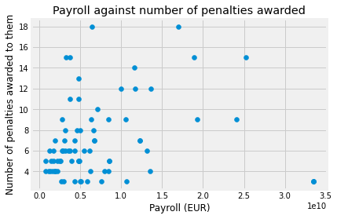

```python
# number of penalties awarded to team against payroll
plt.scatter(SRPC['Payroll_EUR'], SRPC['Num_taken'])
plt.xlabel('Payroll (EUR)')
plt.ylabel('Number of penalties awarded to them')
plt.title('Payroll against number of penalties awarded')
plt.show()
```

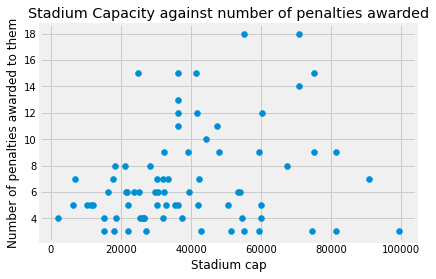

```python
# number of penalties awarded to team against stadium capacity
plt.scatter(SRPC['Stadium cap'], SRPC['Num_taken'])
plt.xlabel('Stadium cap')
plt.ylabel('Number of penalties awarded to them')
plt.title('Stadium Capacity against number of penalties awarded')
plt.show()
```

### Exploring Linear Model

```python
# Splitting the dataset
from sklearn.model_selection import train_test_split
np.random.seed(47)

X_columns = ['Scored_YES', 'Num_taken', 'Payroll_EUR', 'Stadium cap']
SRPC_data = SRPC[X_columns]
X = SRPC_data
Y = pd.Series(SRPC['Succ_rate'])

X_train, X_test, Y_train, Y_test = train_test_split(X, Y, test_size=0.20)
```

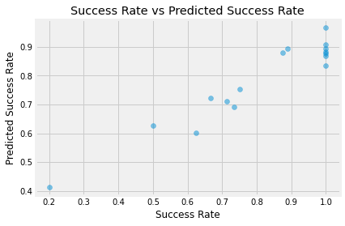

```python
# Quick linear model fitting
import sklearn.linear_model as lm

linear_model = lm.LinearRegression()

# Fit your linear model
linear_model.fit(X_train, Y_train)

# Predict housing prices on the test set
Y_pred = linear_model.predict(X_test)

# Plot predicted vs true prices
plt.scatter(Y_test, Y_pred, alpha=0.5)
plt.xlabel("Success Rate")
plt.ylabel("Predicted Success Rate")
plt.title("Success Rate vs Predicted Success Rate");
```

**Comment:** The Success Rate and predicted Success Rate seems to be on a line. This might indicate a good linear model.

```python
# getting the root mean squared error
def rmse(actual_y, predicted_y):
    """
    Args:
        predicted_y: an array of the prediction from the model
        actual_y: an array of the groudtruth label

    Returns:
        The root mean square error between the prediction and the groundtruth
    """
    return np.sqrt(np.mean((actual_y - predicted_y)**2))

train_error = rmse(Y_train, linear_model.predict(X_train))
test_error = rmse(Y_test, Y_pred)

print("Training RMSE:", train_error)
print("Test RMSE:", test_error)
```

```
Training RMSE: 0.09780639484406435
Test RMSE: 0.10030290104965428
```

**Comment:** The Test RMSE is slightly higher than the training RMSE.

### Adding more features

```python
# adding square and square root of every feature to the design matric=x
SRPC_ext_features = SRPC_data.copy()
for feature_name in SRPC_data.columns:
    SRPC_ext_features[feature_name + "^2"] = SRPC_ext_features[feature_name] ** 2
    SRPC_ext_features["sqrt" + feature_name] = np.sqrt(SRPC_ext_features[feature_name])
SRPC_ext_features.head()
```

| PT team | Scored_YES | Num_taken | Payroll_EUR | Stadium cap | Scored_YES^2 | sqrtScored_YES | Num_taken^2 | sqrtNum_taken | Payroll_EUR^2 | sqrtPayroll_EUR | Stadium cap^2 | sqrtStadium cap |
| --- | --- | --- | --- | --- | --- | --- | --- | --- | --- | --- | --- | --- |
| Lazio | 15 | 18 | 6.411000e+09 | 70634.0 | 225 | 3.873047 | 324 | 4.242641 | 4.110092e+19 | 80068.720484 | 4.989162e+09 | 265.770578 |
| Juventus | 14 | 15 | 2.527600e+10 | 41507.0 | 196 | 3.742188 | 225 | 3.872983 | 6.388762e+20 | 158984.275952 | 1.722831e+09 | 203.732668 |
| Roma | 12 | 14 | 1.158800e+10 | 70634.0 | 144 | 3.464844 | 196 | 3.741657 | 1.342817e+20 | 107647.573126 | 4.989162e+09 | 265.770578 |
| Napoli | 11 | 12 | 1.000600e+10 | 60240.0 | 121 | 3.316406 | 144 | 3.464102 | 1.001200e+20 | 100029.995501 | 3.628858e+09 | 245.438383 |
| Atalanta | 11 | 15 | 3.682000e+09 | 24726.0 | 121 | 3.316406 | 225 | 3.872983 | 1.355712e+19 | 60679.485825 | 6.113751e+08 | 157.245032 |

```python
# fitting the linear model with the extra features
np.random.seed(32)
X = SRPC_ext_features
X_train2, X_test2, Y_train2, Y_test2 = train_test_split(X, Y, test_size = 0.20)
linear_model.fit(X_train2, Y_train2);
```

```python
# calculatin the RMSE again
train_error2 = rmse(Y_train2, linear_model.predict(X_train2))
test_error2 = rmse(Y_test2, linear_model.predict(X_test2))

print("Training RMSE:", train_error2)
print("Test RMSE:", test_error2)
```

```
Training RMSE: 0.1934056286355309
Test RMSE: 0.22788243713079256
```

```python
# get the range of number of features
range_of_num_features = range(1, X_train2.shape[1] + 1)
```

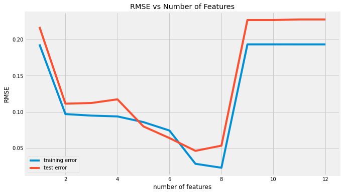

```python
# plotting the graph
train_error_vs_N = []
test_error_vs_N = []

for N in range_of_num_features:
    X_train_first_N_features = X_train2.iloc[:, :N]

    linear_model.fit(X_train_first_N_features, Y_train2)
    train_error_overfit = rmse(Y_train2, linear_model.predict(X_train_first_N_features))
    train_error_vs_N.append(train_error_overfit)

    X_test_first_N_features = X_test2.iloc[:, :N]
    test_error_overfit = rmse(Y_test2, linear_model.predict(X_test_first_N_features))
    test_error_vs_N.append(test_error_overfit)

plt.figure(figsize=(10, 6))
plt.plot(range_of_num_features, train_error_vs_N)
plt.plot(range_of_num_features, test_error_vs_N)
plt.legend(["training error", "test error"])
plt.title('RMSE vs Number of Features')
plt.xlabel("number of features")
plt.ylabel("RMSE");
```

**Comment:** The minimum RMSE for both training and test error is when the number of features is around 7-8. the issue of overfitting is apparent when the number of features go beyond 9.

### Cross-Validation

We are not going to use the plot above to find the optimal number of features. We are going to use cross validation to determine which feature set to use. We are going to consider $2^{12}$ different models.

```python
# getting the mean RMSE from a CV dataset
from sklearn.model_selection import KFold

def compute_CV_error(model, X_train, Y_train):
    '''
    Split the training data into 4 subsets.
    For each subset,
        fit a model holding out that subset
        compute the RMSE on that subset (the validation set)
    You should be fitting 4 models total.
    Return the average RMSE of these 4 folds.

    Args:
        model: an sklearn model with fit and predict functions
        X_train (data_frame): Training data
        Y_train (data_frame): Label

    Return:
        the average validation RMSE for the 4 splits.
    '''
    kf = KFold(n_splits=4)
    validation_errors = []

    for train_idx, valid_idx in kf.split(X_train):
        # split the data
        split_X_train, split_X_valid = X_train.iloc[train_idx, :], X_train.iloc[valid_idx, :]
        split_Y_train, split_Y_valid = Y_train.iloc[train_idx], Y_train.iloc[valid_idx]

        # Fit the model on the training split
        model.fit(split_X_train, split_Y_train)


        # Compute the RMSE on the validation split
        error = rmse(split_Y_valid, model.predict(split_X_valid))


        validation_errors.append(error)

    return np.mean(validation_errors)

compute_CV_error(lm.LinearRegression(),X_train2,Y_train2)
```

```
0.20912027212523748
```

```python
SRPC_ext_features.iloc[:,[1, 3]]
```

| PT team | Num_taken | Stadium cap |
| --- | --- | --- |
| Lazio | 18 | 70634.0 |
| Juventus | 15 | 41507.0 |
| Roma | 14 | 70634.0 |
| Napoli | 12 | 60240.0 |
| Atalanta | 15 | 24726.0 |
| ... | ... | ... |
| Paderborn | 4 | 15000.0 |
| Montpellier | 5 | 32939.0 |
| Brest | 5 | 10169.0 |
| Aston Villa | 3 | 42682.0 |
| Valencia | 3 | 55000.0 |

76 rows × 2 columns

```python
# getting all 2^12 possible combinations of features index
import itertools

combinations = []
index = list(range(12))

for i in range(1, len(index) + 1):
    combinations.extend(list(itertools.combinations(index, i)))

combinations[1000:1005]
```

```
[(0, 3, 4, 5, 9),
 (0, 3, 4, 5, 10),
 (0, 3, 4, 5, 11),
 (0, 3, 4, 6, 7),
 (0, 3, 4, 6, 8)]
```

```python
# getting the best features combination
best_features_index = None
lowest_error = None
for combi in combinations:
    model = lm.LinearRegression()

    # computing the cross validation error
    X_train_selected_features = X_train2.iloc[:, list(combi)]
    error = compute_CV_error(model, X_train_selected_features, Y_train2)

    # updating record if there is better result
    if (not lowest_error) or error < lowest_error:
        best_features_index = combi
        lowest_error = error

print(f"Best features index is {best_features_index} with CV error of {lowest_error}")
```

```
Best features index is (0, 2, 5, 6, 7) with CV error of 0.024356658695938182
```

### Dataset with features of the lowest CV error

```python
X_train_best_features = X_train2.iloc[:, list(best_features_index)]
X_train_best_features.head()
```

| PT team | Scored_YES | Payroll_EUR | sqrtScored_YES | Num_taken^2 | sqrtNum_taken |
| --- | --- | --- | --- | --- | --- |
| Verona | 8 | 2.735000e+09 | 2.828125 | 81 | 3.000000 |
| Lyon | 7 | 6.294000e+09 | 2.646484 | 81 | 3.000000 |
| Nice | 5 | 2.463000e+09 | 2.236328 | 25 | 2.236068 |
| Barcelona | 3 | 3.351800e+10 | 1.732422 | 9 | 1.732051 |
| Lille | 5 | 3.130000e+09 | 2.236328 | 64 | 2.828427 |

**Comment:** Interestingly, we see how the stadium capacity is being ommitted out of the features. This might mean that the stadium capacity does not really have a significant impact on the team's success rate. Moreover, we see how the number of penalties taken appears more than once. This might suggest that teams that have taken more penalty get better at converting their penalties to goals.

**We will be using these selected features for our prediction.**

## Research Question

**Does the number of penalties score, number of penalties taken, team’s payroll (total salary paid annually), and stadium capacity influence the team's penalty success rate?**

## Prediction

```python
# Fitting the linear model
model = linear_model.fit(X_train_best_features, Y_train2)

# Predict points from our test set and calculate the rmse
train_rmse = rmse(Y_train2, model.predict(X_train_best_features))
test_rmse = rmse(Y_test2, model.predict(X_test2.iloc[:, list(best_features_index)]))

print("Train RMSE", train_rmse)
print("KFold Validation RMSE", lowest_error)
print("Test RMSE", test_rmse)
```

```
Train RMSE 0.02313072811953916
KFold Validation RMSE 0.024356658695938182
Test RMSE 0.052427471506924214
```

**Comment:** As we can see, the test RMSE is much lower than our initial test RMSE without feature engineering.

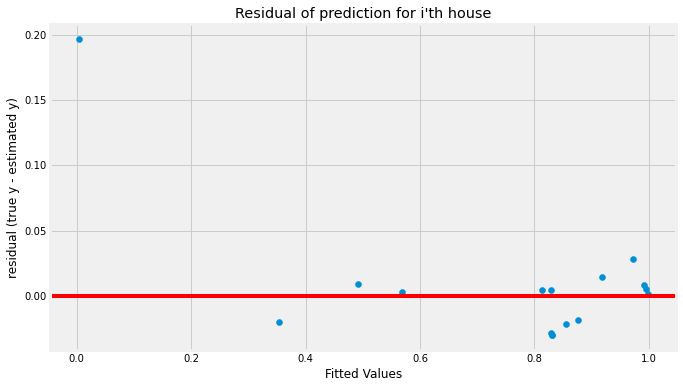

```python
# Plotting the residual plot
plt.figure(figsize=(10, 6))
fitted_values = model.predict(X_test2.iloc[:, list(best_features_index)])
plt.scatter(fitted_values, Y_test2 - fitted_values)
plt.xlabel('Fitted Values')
plt.ylabel('residual (true y - estimated y)')
plt.title("Residual of prediction for i'th house")
plt.axhline(y = 0, color='r');
```

**Comment:** The plots are generally scattered around the line $y = 0$, which is a good indication that the linear regression model is good.

### Predicting

```python
# fill up these parameters
p_num_penalties_taken = 15
p_num_penalties_scored = 15
p_payroll = 1e9

X_predict_data = {
    'Scored_YES': [p_num_penalties_scored],
    'Payroll_EUR': [p_payroll],
    'sqrtScored_YES': [np.sqrt(p_num_penalties_scored)],
    'Num_taken^2': [p_num_penalties_taken^2],
    'sqrtNum_taken': [np.sqrt(p_num_penalties_taken)]

}
X_predict = pd.DataFrame(data = X_predict_data,
                        columns= ['Scored_YES', 'Payroll_EUR', 'sqrtScored_YES', 'Num_taken^2',
       'sqrtNum_taken'])
res = model.predict(X_predict)

print(f"Given the parameters, the success rate is {res[0]}.")
```

```
Given the parameters, the success rate is 0.5685367084642559.
```